# Testing Final

UDEP Project, Brigham Young University

# 1. Poverty

## Income

The overall average income per day is $279.66.

The average income per day for men is $240.48, and the average income per day for women is $330.04. However, the difference is not significant.

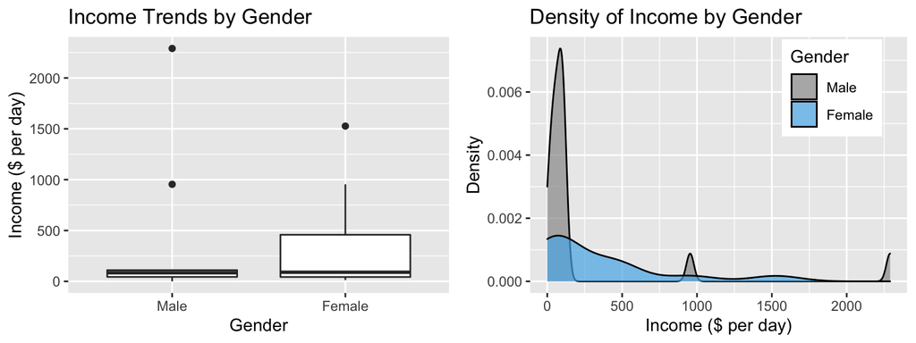

The average income per day for the population ages 0 to 40 is $257.26, and the average income per day for adults is $ 496.18. However, the difference is not significant.

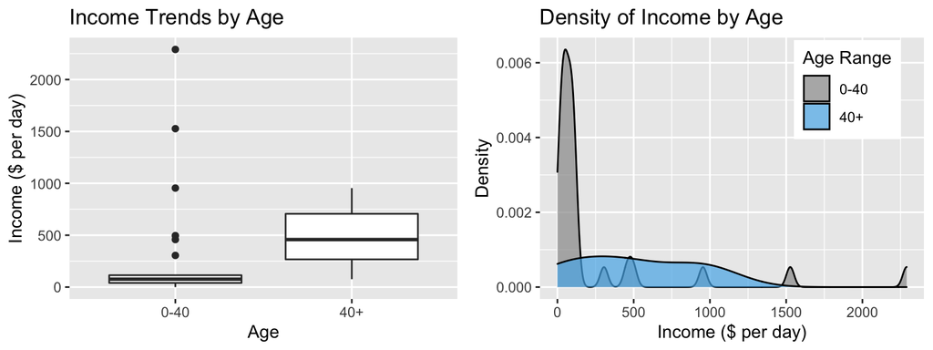

## Access to Facilities

In this sample, 100% of the participants have access to electricity or energy, 100% of the participants have access to water and sanitation, and 100% of the participants have access to refuse and waste removal.

## Land Ownership

21.21% of all the participants own land. 5.56% of men in the sample own land and 40% of women in the sample own land. A difference of means test indicates that significantly more women own land than men.

Additionally, 21.21% of the participants who indicated they own land also have legal documentation that proves the land ownership. 5.56% of men and 40% of women in this smaller sample have the legal documentation. A difference of means indicates that significantly more women who own land have legal documentation of it than men.

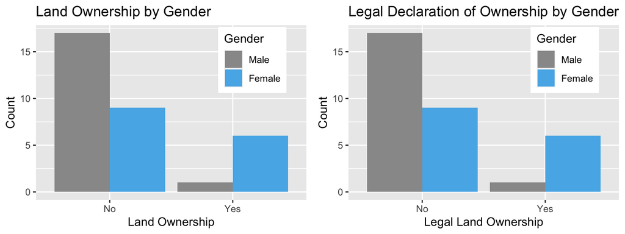

## Comparisons to other Households

When asked to compare their household’s access to basic services (critical services including electricity and energy, water and sanitation, refuse and waste removal) to other households in the community 0% said they had less basic services than most households, 91% said they had about the same amount of basic services as most households, and 9% said they had more basic services than most households.

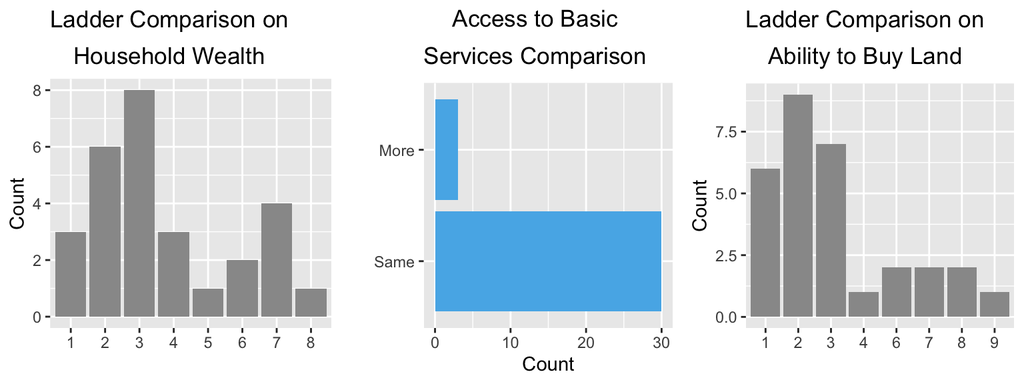

# 2. Hunger

At some point in the past 12 months, 6.06% of the participants have worried about having enough food, 3.03% have been unable to eat nutritious food, and 15.62% have only able to eat a few kinds of food.

Additionally, in the past 12 months, 6.06% of the participants had to skip a meal, 15.15% ate less than they should, and 3.03% ran out of food, all because they did not have enough money.

Finally, in the past 12 months, 0% of the participants were hungry at some point but did not eat and 0% went hungry for an entire day.

## Comparison to other Households

When asked to compare their household’s amount of food to eat to other households in the community 6% said they had less food to eat than most households, 79% said they had about the same amount of food to eat as most households, and 15% said they had more food to eat than most households.

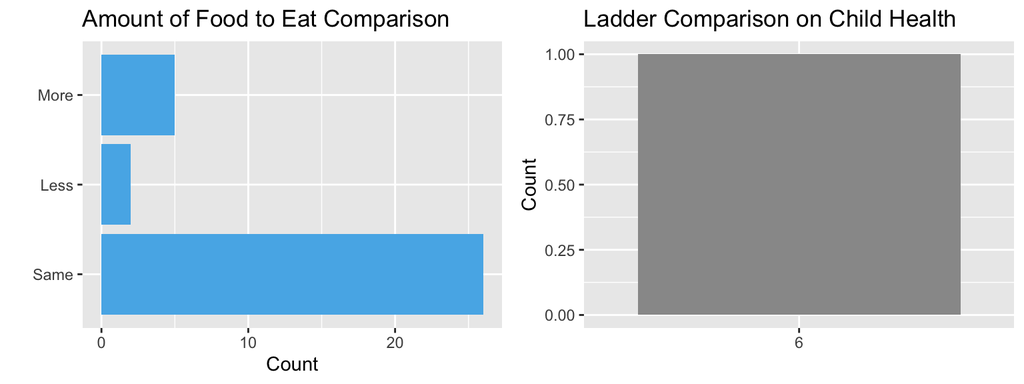

# 3. Healthy Lives

## Fertility and Maternal Health

In the past 12 months, 0% of all participants have given birth, and 0% of 15-19 year olds have given birth. 0% of women who gave birth had the birth attended by skilled staff.

## Diseases

In the sample, 60.61% of participants had a disease. The following are the proportions for specific diseases:

1. HIV - 0 out of 1000 have HIV.
2. Tuberculosis - 0 out of 1000 have tuberculosis.
3. Malaria - 0 out of 1000 have malaria.
4. Hepatitis B - 0 out of 1000 have Hepatitis B.

## Health Care Access

69.7% of the partcipants know of access to substance abuse treatment, 96.88% have access to health coverage, and 87.88% have current health insurance.

Additionally, 100% have access to medication, 100% can afford the medicine their family needs, and 100% can provide medicine when their family needs it.

## Comparison to other Households

When asked to compare their household’s support needed for a healthy birth to other households in the community 0% said they had less support needed for a healthy birth than most households, 0% said they had about the same support needed for a healthy birth as most households, and 0% said they had better support needed for a healthy birth than most households.

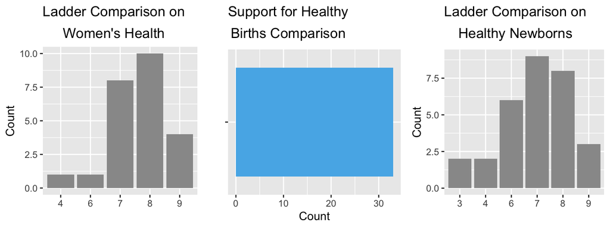

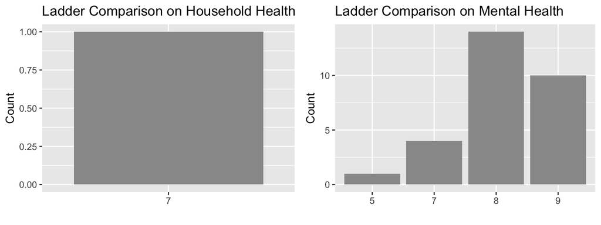

When asked to compare their household’s access to health care to other households in the community 6% said they had worse access to health care than most households, 76% said they had about the same access to health care as most households, and 18% said they had better access to health care than most households.

When asked to compare their household’s access to affordable medications to other households in the community 3% said they had worse access to affordable medications than most households, 76% said they had about the same access to affordable medications as most households, and 21% said they had better access to affordable medications than most households.

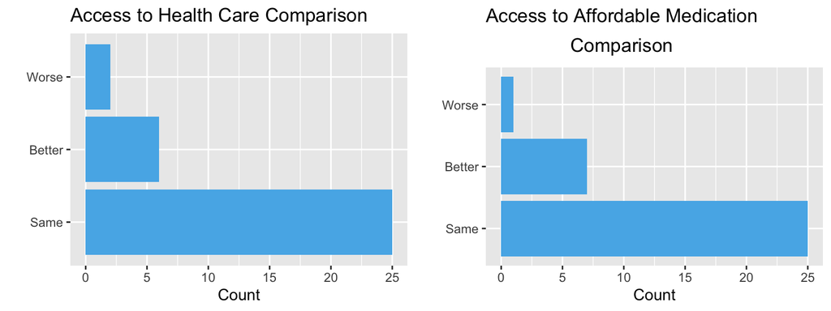

# 4. Quality Education

# Education

100% of households have somebody with at least some grade school completed. The mean household eduction level compared to other households in respondents’ communities is 6.1 on a scale of 1 to 9. The distribution is negatively skewed.

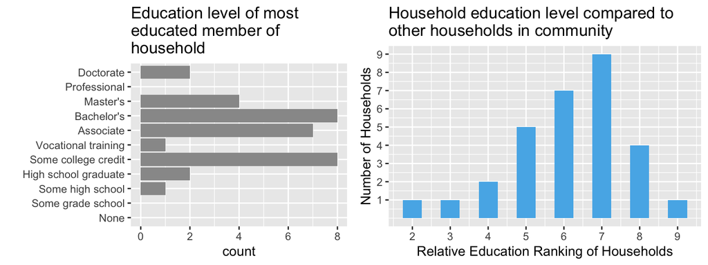

100% of respondents have at least some some grade school completed. There is no difference between the percent of men and women with at least some grade school completed.

90.9% of all the participants have participated in education or vocational training in the past 12 months. 100% of men in the sample have participated and 80% of women in the sample have participated. However, the difference in education/training participation between men and women is not significant.

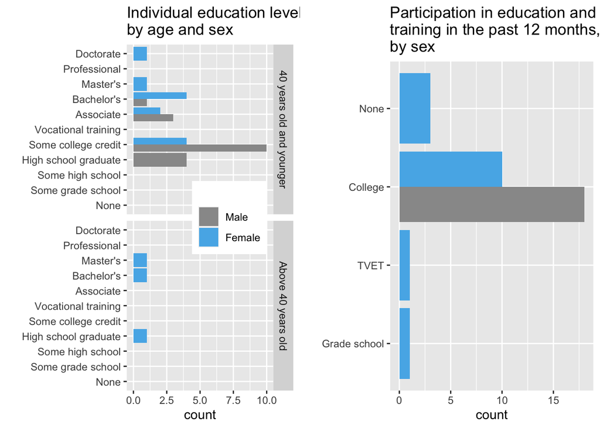

## Computer Activities

Of the following nine computer skills, the average number that each household possesses is 8.5.

- 100% of respondents live with someone able to copy or move a file or folder.
- 100% of respondents live with someone able to use copy and paste tools to duplicate or move information within a document.
- 100% of respondents live with someone able to send e-mails with attached files (e.g. document, picture, video).
- 97% of respondents live with someone able to use basic arithmetic formulae in a spreadsheet.
- 100% of respondents live with someone able to connect and install new devices (e.g. a modem, camera, printer).
- 100% of respondents live with someone able to find, download, install, and configure software.
- 100% of respondents live with someone able to create electronic presentations with presentation software (including text, images, sound, video or charts).
- 97% of respondents live with someone able to transfer files between a computer and other devices.
- 51.5% of respondents live with someone able to Writing a computer program using a specialized programming language.

On a scale of 1 to 9, respondents rate themselves a 7.3 compared to other households in their communities. The variable is approximately normally distributed.

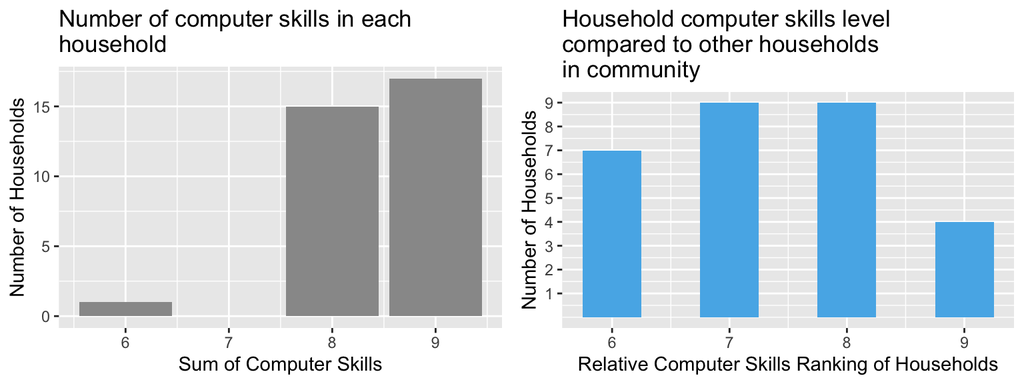

# 5. Gender Equality

36.4% of respondents in the sample are married or joined in a union. 100% of respondents own a mobile phone (100% of men and 100% of women). Of those with a mobile phone, 100% have internet access through their mobile phone.

## Unpaid labor and leadership

25.9% of households have a woman in a management position.

The average amount of unpaid labor per week (such as caregiving, cleaning, errands for the household, and home maintenance) is 15 (10.5 for men; 20.3 for women). The difference between men and women’s hours of unpaid labor is not statistically significant.

### Amount of unpaid labor compared to other women and men in community

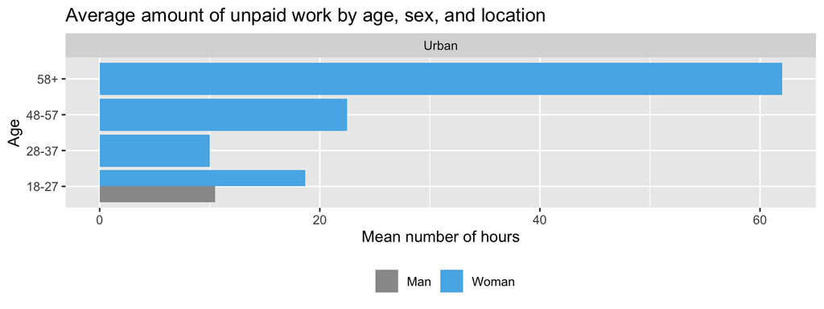

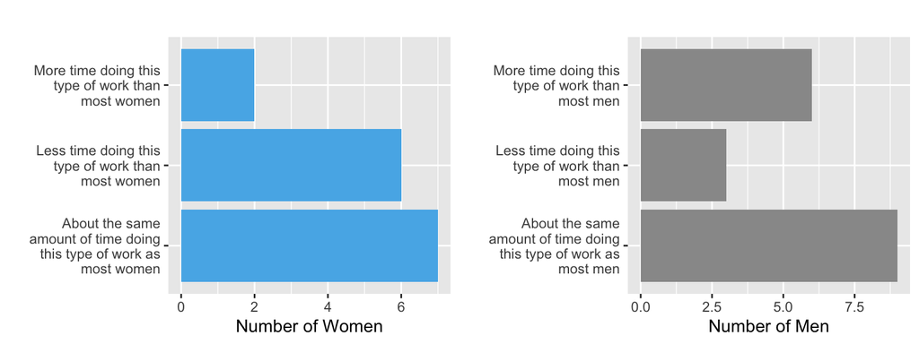

## Physical, Sexual, and Psychological Violoence

In the last 12 months, 0% of married female respondents 15 years and older reported that a household member had been a victim of physical, sexual, or psychological violence. On a scale of 1-9, with 9 being most safe from violence and 1 being least safe, respondents rate their household a 8.5 on average. The distribution is negatively skewed.

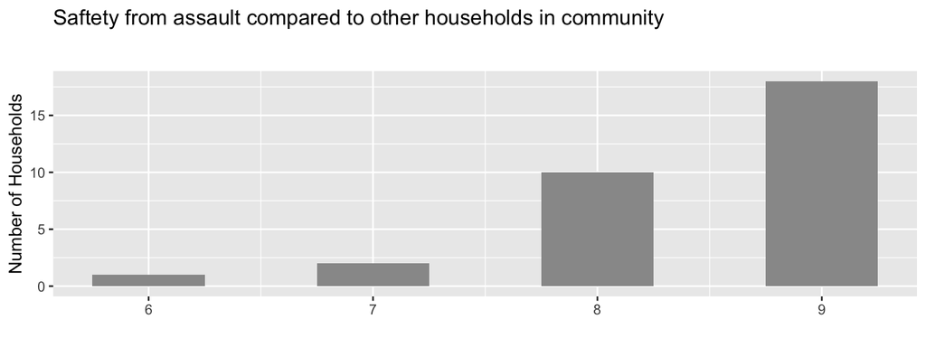

0% of respondents with women in their household indicate that any women or girls in their household have undergone female genital mutilation or cutting. 0% of respondents with women in their household believe that their household has a higher percentage of women who have experienced female genital mutilation or cutting than most households, 60% believe their household is about the same as other households, and 40% believe their household has a lower rate of female genital mutilation or cutting than most households.

## Land ownership

55.6% of female respondents or respondents who reside with a woman feel that the women in their household own about the same amount of property or land as most women in other households within their community, 40.7% feel women in their household own less, and 3.7% feel women in their household own more.

Among households in which a woman resides,3.7% have at least one woman who owns agricultural land. Among households in which at least one woman owns agricultural land, the average number of women who own agrictultural land is 1.

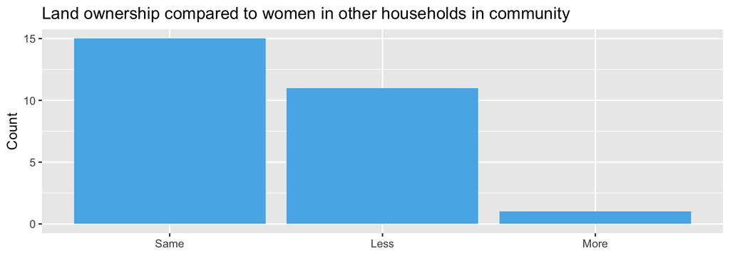

## Reproductive Health and Decision Making

75.8% of respondents know of services that can help them regarding decisions of their sexual relations including contraceptive use and reproductive health. Of those respondents who know of services,100% have access to those services.

100% of women aged 15-49 always feel like they are in control of decisions regarding their sexual relations including contraceptive use and reproductive health.

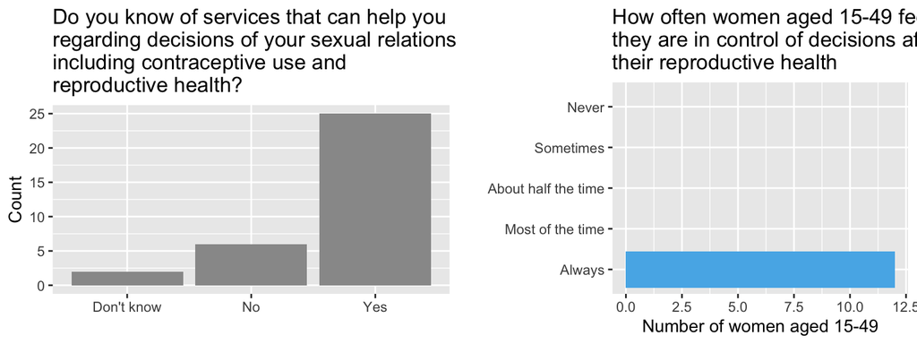

Men are most likely to report having the same amount of control over decisions affecting their reproductive health compared to most men and more control over these decisions than most men.

Women are most likely to report having the same amount of control over decisions affecting their reproductive health compared to most women .

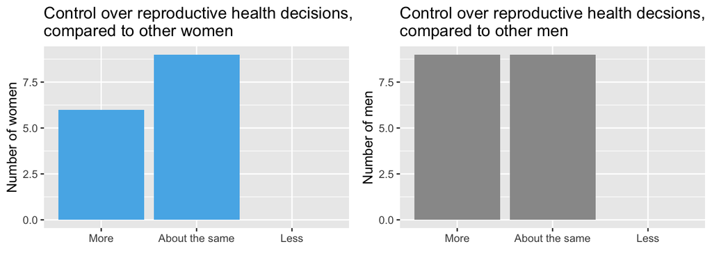

# 6. Clean Water and Sanitation

When asked about how frequently a household members had to drink water they felt was unsafe 82% said never, 15% said rarely (1-2 times in the prior 4 weeks), 0% said sometimes (3-10 times in the prior 4 weeks), 0% said often (11-20 times in the prior 4 weeks), and 3% said always (above 20 times in prior 4 weeks).

When asked about what water sources they had access to 100% of participants said they had access to piped water into thier dwelling, yard or plot, 0% said they had access to public taps or standpipes, 0% said they had access to boreholes or tubewells, 0% said they had access to protected dug wells, and 0% said they had access to protected springs and rainwater.

When asked about restroom facilities 0% said they had access to a flush or pour flush toilet to a sewer system with just hand sanitizer. 97% said they had access to a flush or pour flush toilet to a sewer system with soap and water. The rest of participants either did not respond or used another form of restroom with less access to sanitation.

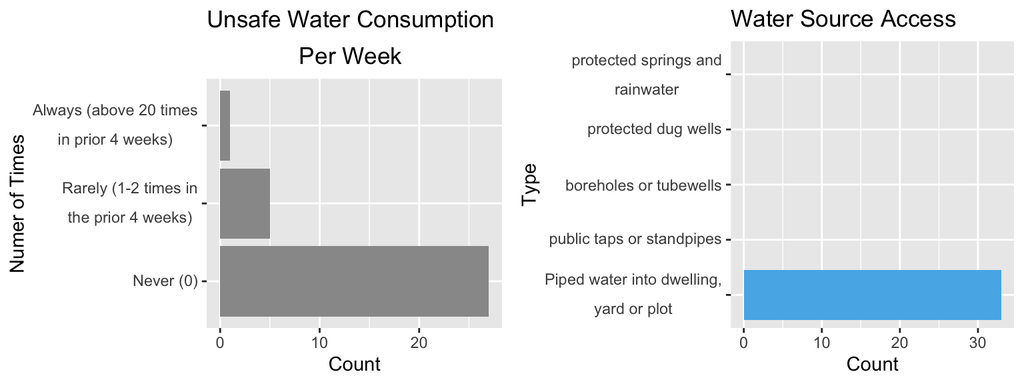

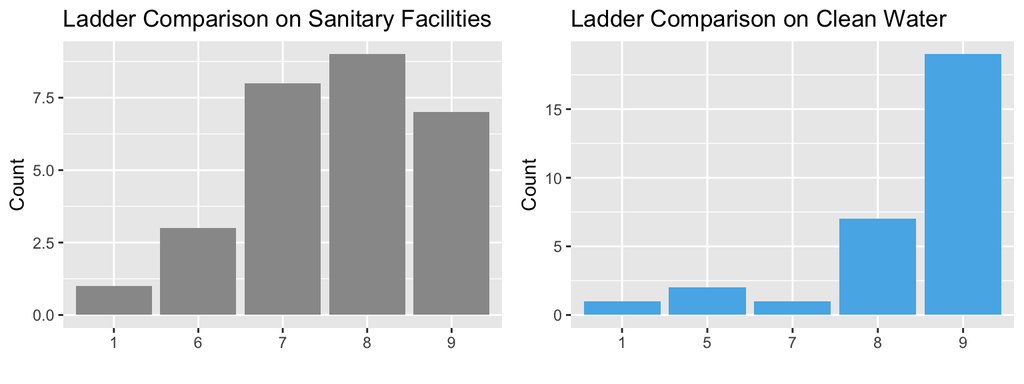

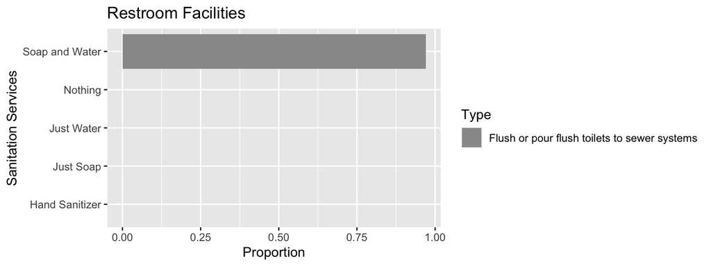

# 7. Affordable and Clean Energy

Of those who reported having access to electricity 38% had access to a national grid connection, 62% had access to a local mini grid connection, 0% had access to an electric generator, 0% had access to a rechargable battery, 0% had access to a dry-cell battery, 0% had access to a solar lantern, 0% had access to a solar multi-light product, 0% had a solar home system, and 0% had access to pico-hydro electricity.

When asked about primary fuel source for cooking 0% of participants said traditional (such as dung, agricultural residue, and fuelwood), 0% said intermediate (such as charcoal and kerosene), and 100% said modern (such as LPG, Biogas, ethanol gas, plant oils, dimethyl ether (DME), and electricity).

When asked about primary fuel source for heating 0% of participants said traditional (such as dung, agricultural residue, and fuelwood), 0% said intermediate (such as charcoal and kerosene), and 100% said modern (such as LPG, Biogas, ethanol gas, plant oils, dimethyl ether (DME), and electricity).

When asked about primary fuel source lighting 0% of participants said traditional (such as dung, agricultural residue, and fuelwood), 0% said intermediate (such as charcoal and kerosene), and 100% said modern (such as LPG, Biogas, ethanol gas, plant oils, dimethyl ether (DME), and electricity).

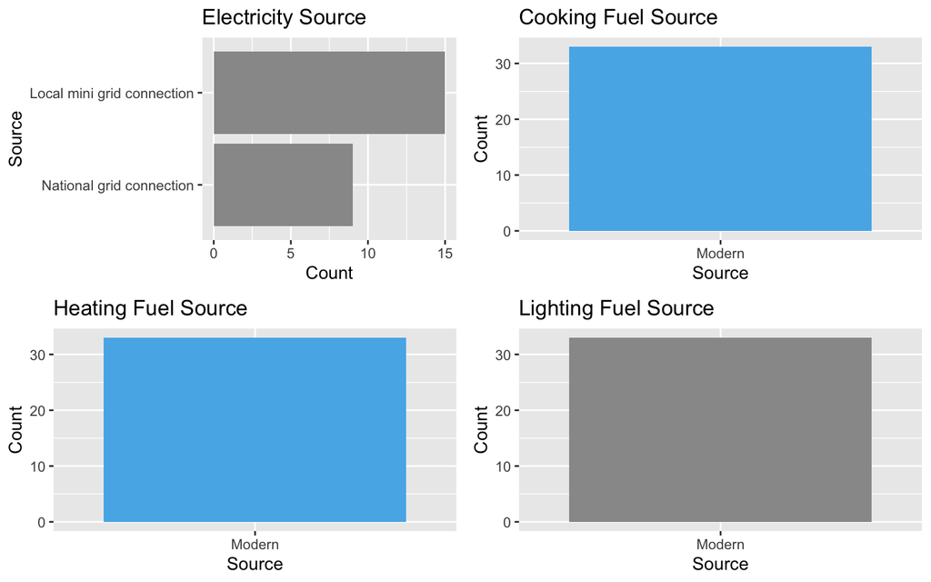

Of those who have access to electricity 68% use electricity mainly for appliances (includes refrigerator, dishwasher, clothes washer and dryer), 0% mainly use it for cooking, 0% mainly use it for entertainment and electronics (includes external power adapters, TVs, home office equipment, computers, and small appliances), 11% mainly use it for heating, and 21% mainly use it for lighting.

When asked to compare thier home’s access to electricity to other households in the community 0% said they had a home with worse access to electricity than most households, 97% said they had a home with about the same access to electricity as most households, and 3% said they had a home with Better access to electricity than most households.

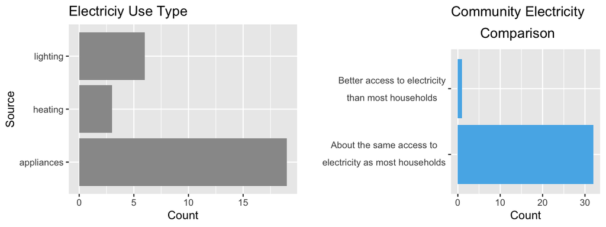

# 8. Decent Work and Economic Growth

## Hourly Wage Differences

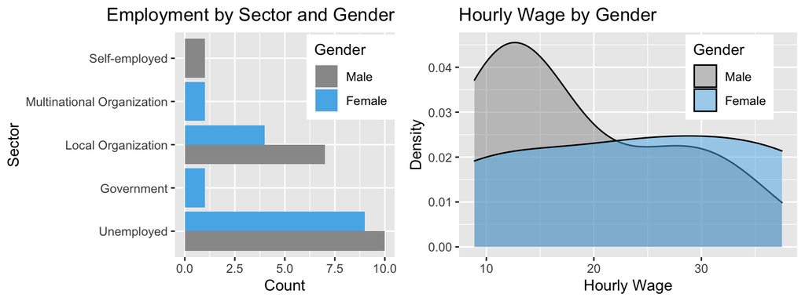

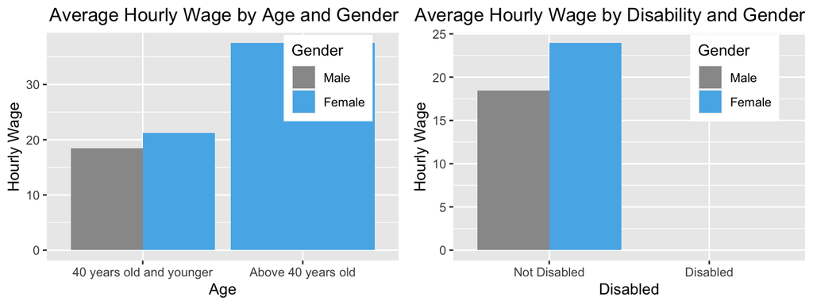

## Access to Banking and Finacial Services

Of all participants above the age of 15 100% have access to a bank, mobile money account, banking/Micro finance account, or loans. 100% have had someone in thier household within the past 12 months that made a finacial transaction using a mobile phone.

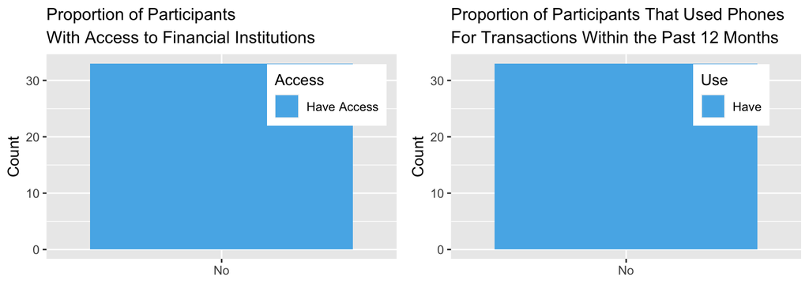

When asked to compare their households access to financial services to other households in the community 0% said they had worse access to financial services than most households, 82% said they had about the same access to financial services as most households, and 18% said they had better access to financial services than most households.

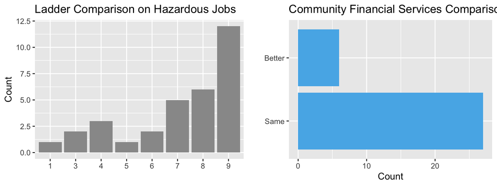

# 9. Reduced Inequalities

Of all participants 0% do not have a place to call home. Of those who have a home 0% have a home that is missing one or more walls or roof and has a dirt floor, 0% have a home that includes temporary walls or roof and has a dirt floor, 100% have a home with solid walls and floor.

When asked what describes their home 0% of participants said my home is too small for my family’s needs, 76% said my home is big enough for my family’s needs, 24% said my home is too big for my family’s needs.

When asked to compare thier home to other households in the community 24% said they had a home less nice than most homes, 61% said they had a home about the same as most homes, and 15% said they had a home nicer than most homes.

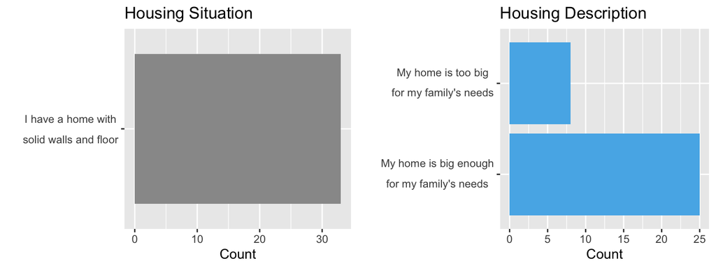

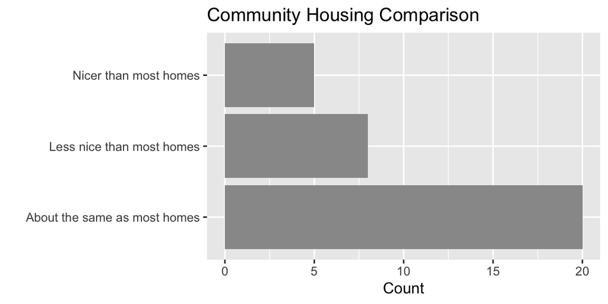